# Objective:

Falls among the elderly is an important health issue. Fall detection and movement tracking are therefore instrumental in addressing this issue. This paper responds to the challenge of classifying different movements as a part of a system designed to fulfill the need for a wearable device to collect data for fall and near-fall analysis. Four different fall trajectories (forward, backward, left and right), three normal activities (standing, walking and lying down) and near-fall situations are identified and detected. Falls are a serious public health problem and possibly life threatening for people in fall risk groups. We develop an automated fall detection system with wearable motion sensor units fitted to the subjects’ body at six different positions. Each unit comprises three tri-axial devices (accelerometer, gyroscope, and magnetometer/compass). To reduce the computational complexity of training and testing the classifiers, we focus on the raw data for each sensor in a 4 s time window around the point of peak total acceleration of the waist sensor, and then perform feature extraction and reduction.

# importing the necessary library

```python
import pandas as pd
import numpy as np
import seaborn as sns
import matplotlib.pyplot as plt
%matplotlib inline
```

# Loading the Data

```python
df_data=pd.read_csv('Train.csv')
```

```python
df_data.head(100)
```

|  | ACTIVITY | TIME | SL | EEG | BP | HR | CIRCLUATION |
| --- | --- | --- | --- | --- | --- | --- | --- |
| 0 | 3 | 4722.92 | 4019.64 | -1600.00 | 13 | 79 | 317 |
| 1 | 2 | 4059.12 | 2191.03 | -1146.08 | 20 | 54 | 165 |
| 2 | 2 | 4773.56 | 2787.99 | -1263.38 | 46 | 67 | 224 |
| 3 | 4 | 8271.27 | 9545.98 | -2848.93 | 26 | 138 | 554 |
| 4 | 4 | 7102.16 | 14148.80 | -2381.15 | 85 | 120 | 809 |
| ... | ... | ... | ... | ... | ... | ... | ... |
| 95 | 4 | 13392.70 | 79963.80 | -5160.00 | 48 | 272 | 3539 |
| 96 | 5 | 9282.91 | 29260.10 | -3378.18 | 31 | 179 | 1626 |
| 97 | 0 | 19176.50 | 299930.00 | -10794.00 | 87 | 407 | 10820 |
| 98 | 0 | 6363.31 | 9414.00 | -2356.00 | 34 | 101 | 586 |
| 99 | 2 | 5398.82 | 4276.59 | -717.00 | 10 | 79 | 317 |

100 rows × 7 columns

```python
df_data.ACTIVITY.unique()
```

```
array([3, 2, 4, 5, 0, 1], dtype=int64)
```

# Exploratory Data Analsyis

```python
#shape of data
df_data.shape
```

```
(16000, 7)
```

```python
#data types of data
df_data.dtypes
```

```
ACTIVITY         int64
TIME           float64
SL             float64
EEG            float64
BP               int64
HR               int64
CIRCLUATION      int64
dtype: object
```

```python
#descriptive info
df_data.describe().transpose()
```

|  | count | mean | std | min | 25% | 50% | 75% | max |
| --- | --- | --- | --- | --- | --- | --- | --- | --- |
| ACTIVITY | 16000.0 | 2.363938 | 1.739124 | 0.000000e+00 | 0.0000 | 3.00 | 4.000 | 5.0 |
| TIME | 16000.0 | 10928.568319 | 5256.510299 | 1.954230e+03 | 7261.7875 | 9768.17 | 13465.375 | 50895.5 |
| SL | 16000.0 | 75013.123044 | 126595.010416 | 4.222420e+01 | 9894.7600 | 30985.30 | 80657.250 | 2426140.0 |
| EEG | 16000.0 | -5649.045131 | 109503.740723 | -1.262600e+07 | -5628.9100 | -3360.00 | -2147.760 | 1410000.0 |
| BP | 16000.0 | 58.246500 | 48.217701 | 0.000000e+00 | 25.0000 | 44.00 | 78.000 | 533.0 |
| HR | 16000.0 | 211.360813 | 129.714908 | 3.300000e+01 | 119.0000 | 180.00 | 271.000 | 981.0 |
| CIRCLUATION | 16000.0 | 2886.907813 | 3802.279749 | 5.000000e+00 | 587.0000 | 1581.00 | 3539.000 | 52210.0 |

# Key insights for descriptive info

Time is positively skewed , possible outliers on RHS

SL is positively skewed , possible outliers on RHS

EEG is Negatively skewed , possible outliers on LHS

BP is positively skewed , possible outliers on RHS

HR is positively skewed , possible outliers on RHS

Circulation is Positively skewed, possible outliers on RHS

# Looking for null values

```python
df_data.isna().sum()
```

```
ACTIVITY       0
TIME           0
SL             0
EEG            0
BP             0
HR             0
CIRCLUATION    0
dtype: int64
```

# Look for any non numeric values

```python
#Checking for any non numeric values
df_data.apply(lambda s: pd.to_numeric(s, errors='coerce').notnull().all())
```

```
ACTIVITY       True
TIME           True
SL             True
EEG            True
BP             True
HR             True
CIRCLUATION    True
dtype: bool
```

This shows that there is no non numeric values present in the data frame

# Perenctile for data frame

```python
df_data.iloc[:,1:7].quantile([.25,.50,.75],axis=0)
```

|  | TIME | SL | EEG | BP | HR | CIRCLUATION |
| --- | --- | --- | --- | --- | --- | --- |
| 0.25 | 7261.7875 | 9894.76 | -5628.91 | 25.0 | 119.0 | 587.0 |
| 0.50 | 9768.1700 | 30985.30 | -3360.00 | 44.0 | 180.0 | 1581.0 |
| 0.75 | 13465.3750 | 80657.25 | -2147.76 | 78.0 | 271.0 | 3539.0 |

# Five point summary, min, max of dataframe columns

```python
#finding interquartile range
iqr=list(map((lambda x: df_data[x].quantile([.75]).iloc[0]-df_data[x].quantile([.25]).iloc[0]),df_data.columns))
df_data_iqr=pd.DataFrame(columns=df_data.columns,data=[iqr],index=['iqr'])
df_data_iqr
```

|  | ACTIVITY | TIME | SL | EEG | BP | HR | CIRCLUATION |
| --- | --- | --- | --- | --- | --- | --- | --- |
| iqr | 4.0 | 6203.5875 | 70762.49 | 3481.15 | 53.0 | 152.0 | 2952.0 |

This tells that any values which lies median+iqr , or median_iqr would be outliers

```python
#finding min value of columm
df_data.min()
```

```
ACTIVITY       0.000000e+00
TIME           1.954230e+03
SL             4.222420e+01
EEG           -1.262600e+07
BP             0.000000e+00
HR             3.300000e+01
CIRCLUATION    5.000000e+00
dtype: float64
```

```python
#Finding max  value
```

```python
df_data.max()
```

```
ACTIVITY             5.0
TIME             50895.5
SL             2426140.0
EEG            1410000.0
BP                 533.0
HR                 981.0
CIRCLUATION      52210.0
dtype: float64
```

# Skewness of the data

```python
#lets verify the skewness of the data
import scipy

df_skew_data=pd.DataFrame(columns=df_data.columns,data=[scipy.stats.skew(df_data)])
df_skew_data
```

|  | ACTIVITY | TIME | SL | EEG | BP | HR | CIRCLUATION |
| --- | --- | --- | --- | --- | --- | --- | --- |
| 0 | -0.172362 | 1.198816 | 4.683337 | -99.641757 | 2.361301 | 1.318266 | 3.071885 |

'Apart from Activity and EEG all the other columns are postively skewed

As of now we will ignore the 'Activity' columns as this is the dependent one.

# Finding outliers in the dataframe

```python
def counting_outliers(df):
    outlier_count=[]
    for item in df:
        q1,q3=df[item].quantile([.25]).iloc[0],df[item].quantile([.75]).iloc[0]
        IQR=q3-q1
        utv,ltv=q3+1.5*IQR,q1-1.5*IQR
        #print ('uthv--->'+str(utv))
        #print ('ltv---->'+str(ltv))
        outlier=[x for x in df[item] if x<ltv or x>utv]
        #print (outlier)
        outlier_count.append(len(outlier))
        print ('number of outliers for-->'+str(item)+'-->is:'+str(len(outlier)))
    return outlier_count
```

# Outlier count

```python
#using the function counting_outliers to count the number of outliers across each column
a=counting_outliers(df_data)
df_outlier_count=pd.DataFrame(columns=df_data.columns,data=[a])
df_outlier_count
```

```
number of outliers for-->ACTIVITY-->is:0
number of outliers for-->TIME-->is:611
number of outliers for-->SL-->is:1544
number of outliers for-->EEG-->is:899
number of outliers for-->BP-->is:661
number of outliers for-->HR-->is:634
number of outliers for-->CIRCLUATION-->is:1298
```

|  | ACTIVITY | TIME | SL | EEG | BP | HR | CIRCLUATION |
| --- | --- | --- | --- | --- | --- | --- | --- |
| 0 | 0 | 611 | 1544 | 899 | 661 | 634 | 1298 |

As detected from our skew data , we now can see confirm that we have outliers present in

'Time','SL','EEG','BP','HR','CIRCULATION'

Now lets visualize it via box plot

# Visualizing the outliers

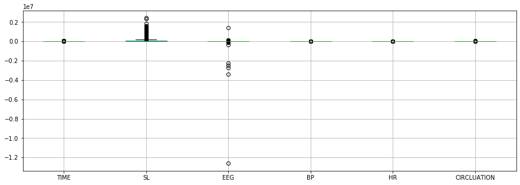

```python
outlier_columns=(df_outlier_count.loc[:, (df_outlier_count != 0).all(axis=0)].columns).tolist()
outlier_columns
df_data.boxplot(column=outlier_columns,figsize=(15,5))
```

# OBSERVATION ON OUTLIERS

There are large number of outliers present in SL, EEG particularly.

We will try to handle them

# Replacing outliers

```python
def replacing_outliers(df):
    outlier_count=[]
    for item in df.iloc[:,1:7]:
        print (item)
        df[item]=df[item].mask((df[item] - df[item].mean()).abs()> 1.5 * df[item].std(),axis=0)
```

```python
#replacing_outliers(df_data)
df_data.isna().sum()
```

```
ACTIVITY       0
TIME           0
SL             0
EEG            0
BP             0
HR             0
CIRCLUATION    0
dtype: int64
```

```python
#Handling the outliers by replacing them with median value

#df_data=df_data.apply(lambda x:x.fillna(x.std()*2))
df_data=df_data.apply(lambda x:x.fillna(x.median()))

df_data.isna().sum()
```

```
ACTIVITY       0
TIME           0
SL             0
EEG            0
BP             0
HR             0
CIRCLUATION    0
dtype: int64
```

```python
df_data.iloc[:,1:7]
```

|  | TIME | SL | EEG | BP | HR | CIRCLUATION |
| --- | --- | --- | --- | --- | --- | --- |
| 0 | 4722.92 | 4019.64 | -1600.00 | 13 | 79 | 317 |
| 1 | 4059.12 | 2191.03 | -1146.08 | 20 | 54 | 165 |
| 2 | 4773.56 | 2787.99 | -1263.38 | 46 | 67 | 224 |
| 3 | 8271.27 | 9545.98 | -2848.93 | 26 | 138 | 554 |
| 4 | 7102.16 | 14148.80 | -2381.15 | 85 | 120 | 809 |
| ... | ... | ... | ... | ... | ... | ... |
| 15995 | 8063.69 | 19109.00 | -3694.00 | 16 | 165 | 1073 |
| 15996 | 8993.13 | 20703.00 | -4020.00 | 21 | 164 | 1111 |
| 15997 | 12579.50 | 73377.70 | -4040.00 | 25 | 249 | 3630 |
| 15998 | 14372.90 | 45448.10 | -2740.00 | 60 | 190 | 1573 |
| 15999 | 7646.39 | 14032.10 | -2315.56 | 83 | 120 | 809 |

16000 rows × 6 columns

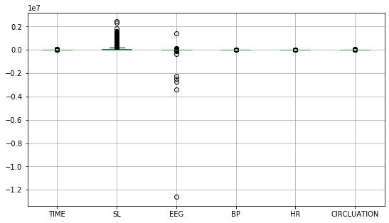

```python
outlier_columns=(df_outlier_count.loc[:, (df_outlier_count != 0).all(axis=0)].columns).tolist()
outlier_columns
df_data.boxplot(column=outlier_columns,figsize=(9,5))
```